# Place-Level Voter Turnout

### Interpolation

We use the following specification for the areal interpolation; however, we manually do the interpolation so we can use the weights to construct a quality variable.

```r
# Interpolate using only our 485 cities
result <- aw_interpolate(.data = my_places,    # target shapes
                         tid = GEOID,          # target id
                         source = precincts,   # source shapes
                         sid = GEOID16,        # source id
                         weight = "total",
                         output = "tibble",
                         extensive = c("total_votes", "zm_flag", "invalid_flag"))
```

An example of areal interpolation using the following steps is available [here](https://cran.r-project.org/web/packages/areal/vignettes/areal-weighted-interpolation.html).

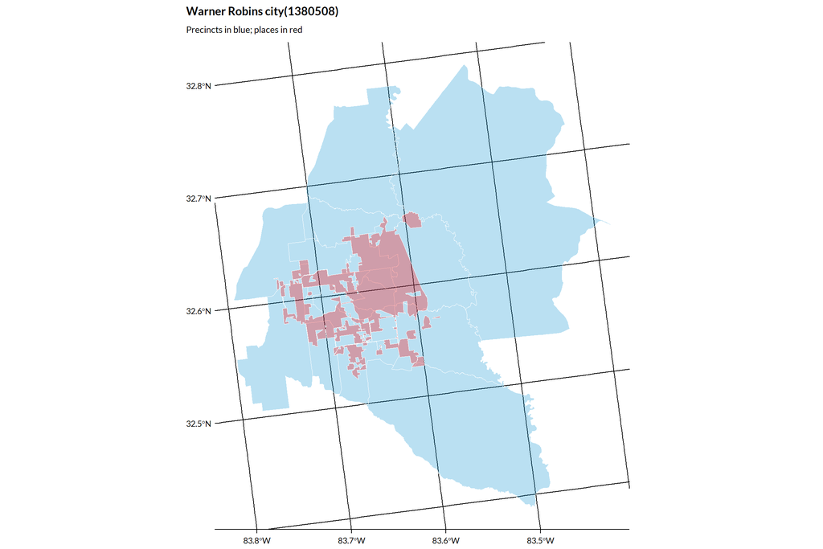

```r
int <- aw_intersect(
  .data = my_places,
  source = precincts,
  areaVar = "area"
)

tot <- aw_total(
  .data = int,
  source = precincts,
  id = GEOID16,
  areaVar = "area",
  totalVar = "totalArea",
  type = "extensive",
  weight = "total"
)

weight <- aw_weight(
  .data =  tot,
  areaVar = "area",
  totalVar = "totalArea",
  areaWeight = "areaWeight"
)

result <- weight %>%
  st_drop_geometry() %>%
  mutate(total_votes = total_votes * areaWeight) %>%
  group_by(state, place, state_name, place_name, GEOID) %>%
  mutate(weight = total_votes / sum(total_votes)) %>%
  summarize(
    total_votes = sum(total_votes),
    messiness = weighted.mean(
      x = 0.5 - abs(areaWeight - 0.5),
      w = weight
    )
  ) %>%
  ungroup()


map_trouble("1380508")
```

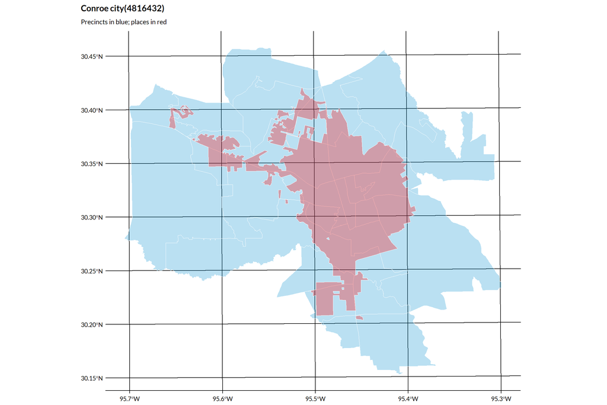

```r
map_trouble("4816432")
```

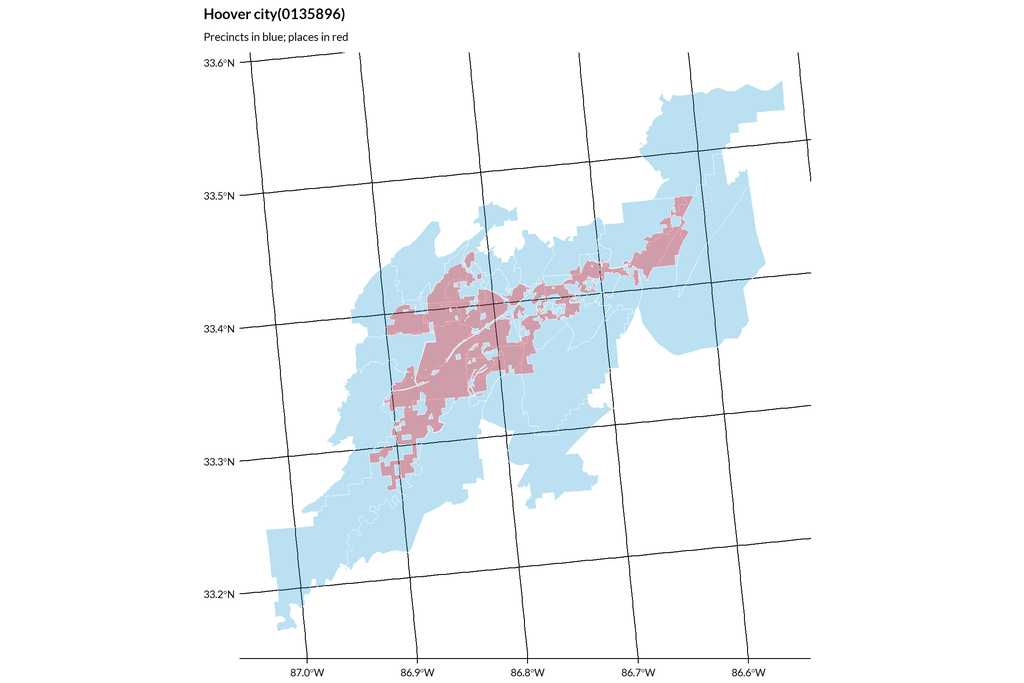

```r
map_trouble("0135896")
```

### Quality Checks

#### Compare Places with Independent Cities and Counties

Get the MIT Election Lab county-level data for 2016.

```r
# Download MIT Election Lab county-level returns. This code is copied directly from `voter-turnout-2016.Rmd` which used the same data

# download the data from the Harvard dataverse
mit_directory <- here::here("05_local-governance",
                        "voter-turnout",
                        "data",
                        "temp")

mit_data <- here::here("05_local-governance",
                        "voter-turnout",
                        "data",
                        "temp",
                        "countypres_2000-2016.csv")

if (!dir.exists(mit_directory)) {

  dir.create(mit_directory, recursive = TRUE)

}

if (!file.exists(mit_data)) {

  download.file(
    "https://dataverse.harvard.edu/api/access/datafile/3641280?format=original&gbrecs=true",
    destfile = mit_data
  )

}
```

There are a few independent cities and counties in our data set. In these cases, the census place perfectly matches a county and we can pull the county results and compare them to the interpolated place results.

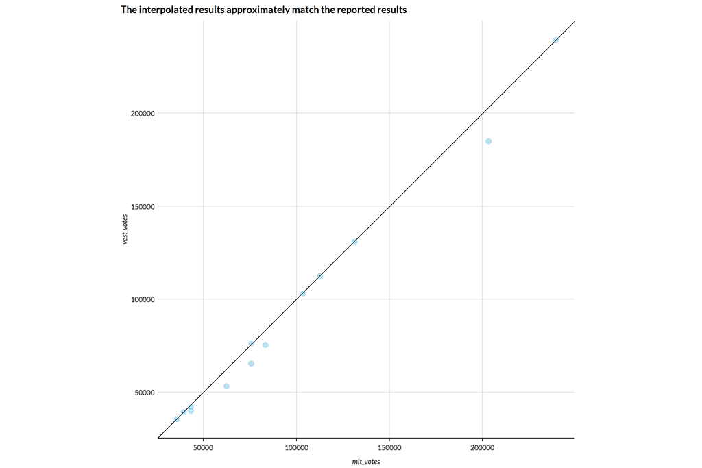

```r
# pull county results
mit <- read_csv(here::here("05_local-governance",
                           "voter-turnout",
                           "data",
                           "temp",
                           "countypres_2000-2016.csv")) %>%
  filter(year == 2016) %>%
  group_by(FIPS) %>%
  summarize(votes = sum(candidatevotes)) %>%
  mutate(FIPS = as.character(FIPS)) %>%
  rename(county_fips = FIPS)

# pull crosswalk to make join possible
place_to_county <- read_csv(here::here("geographic-crosswalks", "data", "county-populations.csv")) %>%
  filter(year == 2016) %>%
  select(state, county, county_name)

# join data
independent_results <- result %>%
  left_join(place_to_county, by = c("state", "place_name" = "county_name")) %>%
  filter(!is.na(county)) %>%
  mutate(county_fips = paste0(state, county)) %>%
  left_join(mit, by = "county_fips")

# compare data
independent_results %>%
  ggplot(aes(votes, total_votes)) +
  geom_abline() +
  geom_point(alpha = 0.3) +
  labs(
    title = "The interpolated results approximately match the reported results",
    x = "mit_votes",
    y = "vest_votes"
  ) +
  coord_equal() +
  scatter_grid()
```

# 2. Denominator

The denominator for the analysis should be the total age-eligible citizen population ([data here](https://www.census.gov/programs-surveys/decennial-census/about/voting-rights/cvap.2020.html))

The US Census Bureau creates a special tabulation of the 2016-2020 ACS that includes county-level estimates of the total number of United States citizens 18 years of age or older. They also report estimates for subgroups within counties and for other geographic areas.

If the data are not downloaded, then we download and unzip the data.

```r
# increase timeout for download
options(timeout = 300)

cvap_zip <- here::here("05_local-governance",
                       "voter-turnout",
                       "data", "temp",
                       "CVAP_2016-2020_ACS_csv_files.zip")

cvap_data <- here::here("05_local-governance",
                        "voter-turnout",
                        "data", "temp",
                        "CVAP_2016-2020_ACS_csv_files")

if (!file.exists(cvap_data)) {

  download.file(url = "https://www2.census.gov/programs-surveys/decennial/rdo/datasets/2020/2020-cvap/CVAP_2016-2020_ACS_csv_files.zip",
                destfile = cvap_zip)

  unzip(zipfile = cvap_zip,
        exdir = cvap_data)

  file.remove(cvap_zip)

}
```

```
## [1] TRUE
```

Next, we load and clean the data. The variable of interest is `cvap_est`.

> cvap_est: The rounded estimate of the total number of United States citizens 18 years of age or older for that geographic area and group.

```r
cvap <- read_csv(here::here("05_local-governance",
                            "voter-turnout",
                            "data", "temp",
                            "CVAP_2016-2020_ACS_csv_files",
                            "Place.csv"))

cvap <- cvap %>%
  tidylog::filter(lntitle == "Total") %>%
  select(-lntitle, -lnnumber)

cvap <- cvap %>%
  mutate(state = str_sub(string = geoid, start = 10, end = 11),
         place = str_sub(string = geoid, start = -5, end = -1),
         GEOID = str_c(state, place))

cvap <- cvap %>%
  tidylog::filter(state != "72") %>% #Drop Puerto Rico
  select(state,
         place,
         GEOID,
         cvap = cvap_est,
         cvap_moe)
```

# 3. Combine and calculate turnout

We combine the data. The join works for all places.

```r
joined_data <- left_join(result, cvap, by = c("GEOID", "state", "place"))
```

We calculate turnout and the coefficient of variation for the CVAP estimate.

```r
joined_data <- joined_data %>%
  mutate(election_turnout = total_votes / cvap) %>%
  mutate(cv = (cvap_moe / 1.645) / cvap)
```

No observations have voter turnout above `1`.

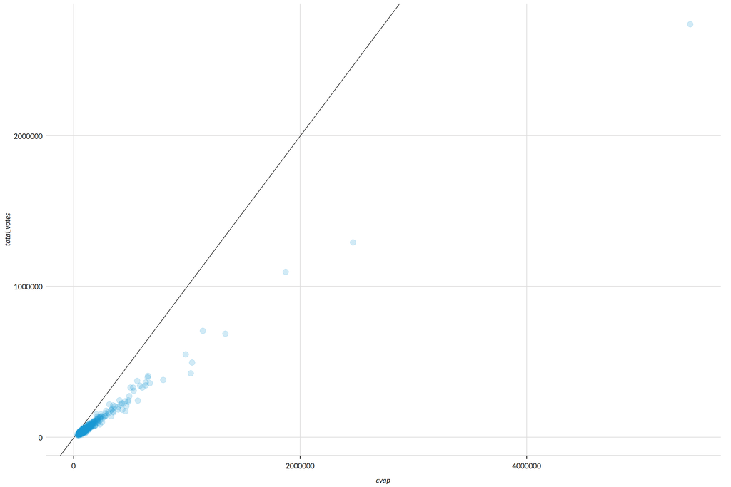

```r
joined_data %>%
  ggplot(aes(cvap, total_votes)) +
  geom_abline() +
  geom_point(alpha = 0.2) +
  scatter_grid()
```

```r
joined_data %>%
  filter(total_votes > cvap)
```

```
## # A tibble: 0 × 11
## # ℹ 11 variables: state <chr>, place <chr>, state_name <chr>, place_name <chr>,
## #   GEOID <chr>, total_votes <dbl>, messiness <dbl>, cvap <dbl>,
## #   cvap_moe <dbl>, election_turnout <dbl>, cv <dbl>
```

**Check:** Is voter turnout bounded by 0 and 1 inclusive

```r
stopifnot(!any(joined_data$election_turnout > 1))
```

```r
stopifnot(
  max(joined_data$election_turnout, na.rm = TRUE) <= 1
)

stopifnot(
  min(joined_data$election_turnout, na.rm = TRUE) >= 0
)
```

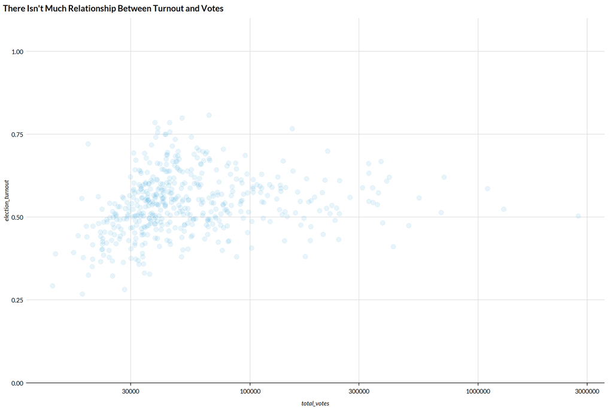

```r
joined_data %>%
  ggplot(aes(total_votes, election_turnout)) +
  geom_point(alpha = 0.1) +
  scale_x_log10() +
  scale_y_continuous(limits = c(0, 1),
                     expand = expansion(mult = c(0, 0.1))) +
  scatter_grid() +
  labs(title = "There Isn't Much Relationship Between Turnout and Votes")
```

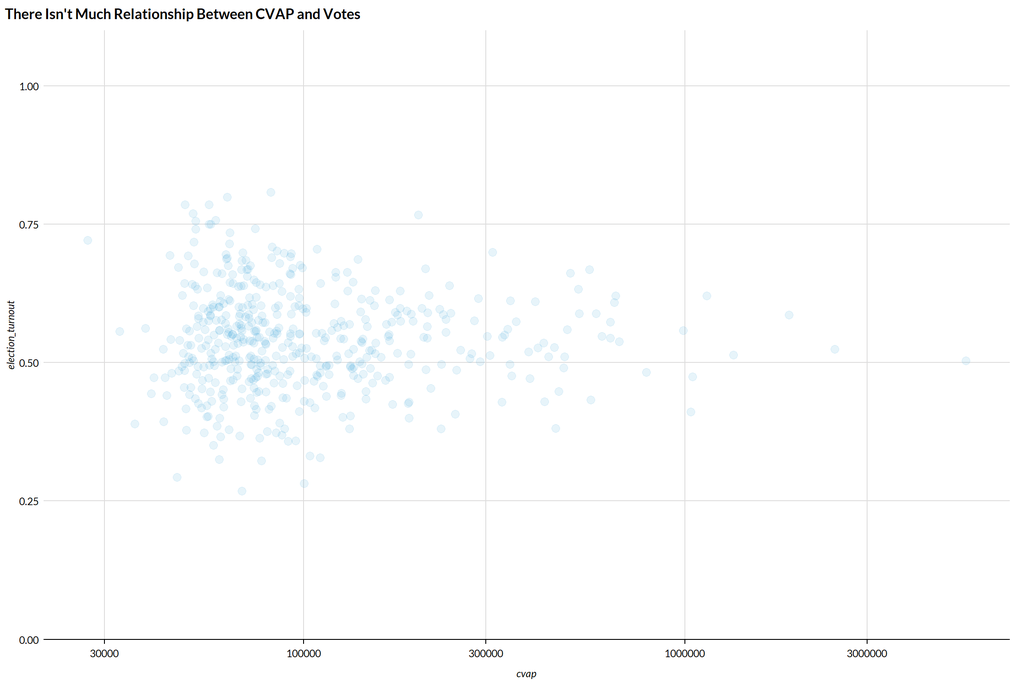

```r
joined_data %>%
  ggplot(aes(cvap, election_turnout)) +
  geom_point(alpha = 0.1) +
  scale_x_log10() +
  scale_y_continuous(limits = c(0, 1),
                     expand = expansion(mult = c(0, 0.1))) +
  scatter_grid() +
  labs(title = "There Isn't Much Relationship Between CVAP and Votes")
```

# 4. Quality flags

We consider three dimensions when evaluating the quality of the constructed metric.

1. The precision of the denominator.
2. The process used to create VEST data.
3. The quality of the areal interpolation.

## 1. The precision of the denominator

Sampling error in the denominator is definitely a concern for small places. We flag cases with high and very high coefficients of variation in the denominator.

- `1` No issue
- `2` CV >= 0.05
- `3` CV >= 0.15

There isn’t much consensus on critical values for coefficients of variation. We use `0.15` because it is mentioned [A Compass for Understanding and Using American Community Survey Data](https://www.census.gov/content/dam/Census/library/publications/2009/acs/ACSstateLocal.pdf).

> While there is no hard-and-fast rule, for the purposes of this handbook, estimates with CVs of more than 15 percent are considered cause for caution when interpreting patterns in the data.

If anything, a stricter threshold is necessary because the estimates are used in denominators. Thus, we use `0.05` for a `2`.

```r
joined_data <- joined_data %>%
  mutate(
    denominator_quality = case_when(
      is.na(election_turnout) ~ NA_real_,
      cv >= 0.15 ~ 3,
      cv >= 0.05 ~ 2,
      TRUE ~ 1
    )
  )
```

## 2. The process used to create VEST data

We assign a quality of `1` to the VEST data as no significant interpolation were reported for the data.

```r
joined_data <- joined_data %>%
  mutate(
    allocation_quality = 1
    )
```

## 3. The quality of the areal interpolation

The quality of the numerator may be a concern for precincts with Z/M features in their geometry or with an invalid geometry. We already created flags for these cases.

We calculated a messiness measure during the areal interpolation. Precincts that mostly or barely intersect a place are ideal because the assumption of an evenly distributed population matters the least. A precinct that is only half inside a place is concerning.

```r
joined_data <- joined_data %>%
  mutate(
    interpolation_quality =
      case_when(
        messiness < 0.05 ~ 1,
        messiness < 0.1 ~ 2,
        TRUE ~ 3
      )
    )
```

Let’s look at each of the quality variables.

```r
count(
  joined_data,
  interpolation_quality,
  allocation_quality,
  denominator_quality
)
```

```
## # A tibble: 3 × 4
##   interpolation_quality allocation_quality denominator_quality     n
##                   <dbl>              <dbl>               <dbl> <int>
## 1                     1                  1                   1   418
## 2                     2                  1                   1    38
## 3                     3                  1                   1    29
```

Let’s use the worst of the three quality tests to set the quality.

```r
joined_data <- joined_data %>%
  mutate(election_turnout_quality = pmax(interpolation_quality, allocation_quality, denominator_quality))
```

## 4. Explore data quality

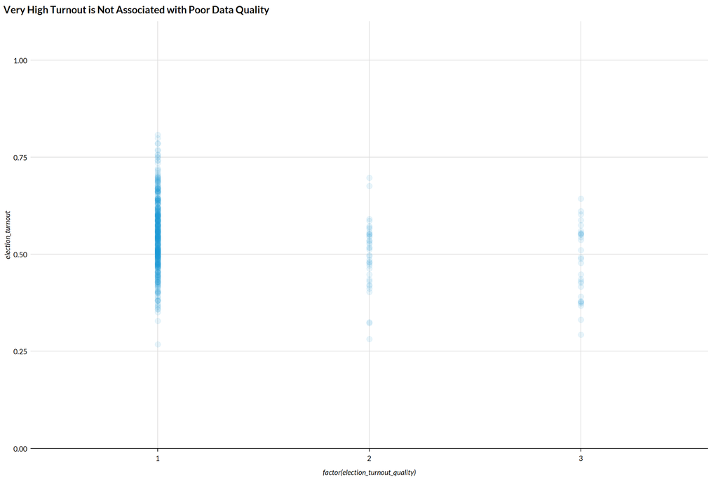

```r
joined_data %>%
  ggplot(aes(factor(election_turnout_quality), election_turnout)) +
  geom_point(alpha = 0.1) +
  scale_y_continuous(limits = c(0, 1),
                     expand = expansion(mult = c(0, 0.1))) +
  scatter_grid() +
  labs(title = "Very High Turnout is Not Associated with Poor Data Quality")
```

# 5. Evaluate and save the data

```r
final_data <- joined_data %>%
                  mutate(year = 2016) %>%
                  select(
                          year, state, place,
                          share_election_turnout = election_turnout,
                          share_election_turnout_quality = election_turnout_quality
                         )
```

We need to evaluate the final data outputs using the `evaluate_final_data` function per UMF [guidelines](https://github.com/UI-Research/mobility-from-poverty/wiki/8_Final-Data-Expectations-Form%E2%80%AF).

```r
evaluate_final_data(
    exp_form_path =
      here::here("10a_final-evaluation", "evaluation_form_election_turnout_overall_place.csv"),
    data = final_data, geography = "place",
    subgroups = FALSE, confidence_intervals = TRUE)
```

```
## [1] "This data passes all tests!"
```

Write the final output data file.

```r
file_path <- (here::here("05_local-governance",
                       "voter-turnout", "data",
                       "final",
                       "voter-turnout-city-2016.csv"))

# Create final data folder if it doesn't exist
if (!dir.exists(dirname(file_path))) {

  dir.create(dirname(file_path))

}

# Save the csv file
write.csv(final_data, file_path, row.names = FALSE)
```

# Sources

[Mismatched: The Trouble with Making a National Precinct Return Shapefile](https://medium.com/mit-election-lab/mismatched-the-trouble-with-making-a-national-precinct-return-shapefile-fc16a3d3ff94)

[2016 Precinct-Level Election Results from the Voting and Election Science Team at University of Florida and Wichita State University](https://dataverse.harvard.edu/dataset.xhtml?persistentId=doi:10.7910/DVN/NH5S2I)

[Documentation for above data](https://dataverse.harvard.edu/file.xhtml?fileId=10596694&version=94.0)

[sf:: cheat sheet](https://github.com/rstudio/cheatsheets/blob/main/sf.pdf)

[Geocomputation with R - Spatial data operations](https://geocompr.robinlovelace.net/spatial-operations.html#incongruent)

[Areal Weighted Interpolation](https://cran.r-project.org/web/packages/areal/vignettes/areal-weighted-interpolation.html)

[Precinct-Level Election Data Project](https://web.stanford.edu/~jrodden/jrhome_files/electiondata.htm)